# Лабораторная работа № 6

Управление процессами

Чжао Синья

Российский университет дружбы народов

2026-10-17

# Информация

## Докладчик

- Чжао Синья
- Группа: НПИбд-03-25
- Направление: Прикладная информатика
- РУДН им. П. Лумумбы
- Студенческий билет: 1132258332

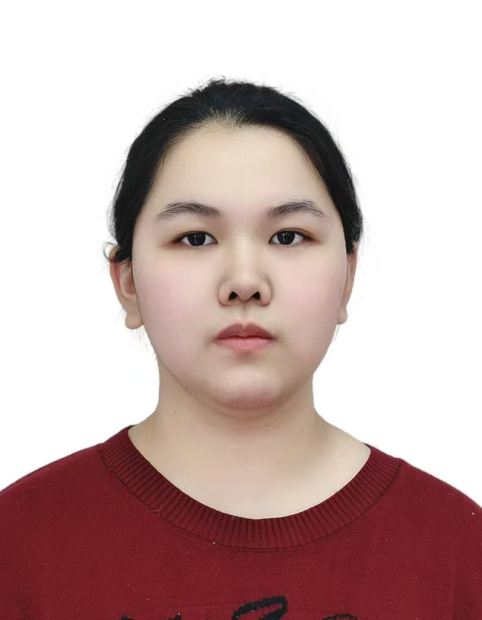

Фото автора

# Вводная часть

## Актуальность и объект

- **Актуальность:** Управление процессами и заданиями — ключевой навык для оптимизации ресурсов и диагностики Linux.
- **Объект исследования:** Процессы и задания в операционной системе.
- **Предмет исследования:** Команды `ps`, `jobs`, `top`, `nice`, `renice`, `nohup`, `kill`.

## Научная новизна и значимость

- **Научная новизна:** Изучение механизмов работы фоновых процессов, приоритетов и сигналов (например, `SIGHUP`).
- **Практическая значимость:** Навыки запуска долгих задач в фоне и их корректного завершения.

## Цели и задачи

- **Цель:** Получить навыки управления процессами ОС.
- **Задачи:**
  - Освоить управление заданиями оболочки.
  - Освоить управление процессами и их приоритетами.
  - Выполнить задания для самостоятельной работы.

## Материалы и методы

- Операционная система: Linux (bash)
- Инструменты: `ps`, `top`, `jobs`, `fg`, `bg`, `nice`, `renice`, `nohup`, `kill`, `killall`

# Выполнение работы

## Управление заданиями

- Запуск фоновых задач: `sleep 3600 &`, `dd &`, `sleep 7200`.
- Приостановка: `Ctrl + Z`.
- Просмотр статуса: `jobs`.
- Управление задачами: `bg`, `fg`, `Ctrl + C`.

## Управление процессами

- Поиск процессов: `ps aux | grep dd`.
- Изменение приоритета: `renice -n 5 <PID>`.
- Иерархия процессов: `ps fax | grep -B5 dd`.
- Завершение родительского процесса убивает всех потомков (`kill -9`).

## Самостоятельная работа

- Изменение приоритета `dd` на `-5` и `-15`.
- Запуск `yes` в фоне и на переднем плане.
- Использование `nohup` для независимости от терминала.
- Управление приоритетами `yes` и сравнение NI/PRI.
- Завершение процессов по PID, номеру задания и имени (`killall`).

# Заключение

## Выводы

- Освоены команды управления заданиями: `jobs`, `bg`, `fg`.
- Освоен просмотр процессов: `ps`, `top`.
- Изменены приоритеты процессов с помощью `nice` и `renice`.
- Проверена работа `nohup`, `kill`, `killall`.
- **Все задачи выполнены в полном объеме.**